# SiS: Problemes en grup, ELIMINACIÓ D'ECO

2020-2021 \ Pol Costa, Pol Rosinés, Pol Vilavella, Pau Tarragó

#### **a) Donat $y[n] = x[n] + ax[n-N]$ trobeu la resposta impulsional $h_1[n]$:**

$$ y[n] = x[n] + ax[n-N] \\ y[n] = x[n]*h_1[n] \implies h_1[n] = \delta[n] + a[n-N] $$

#### **b) Donat $z[n] = y[n] -bz[n-N]$ trobeu la resposta impulsional $h_2[n]$:**

$$ z[n] = y[n] -bz[n-N] $$

Per trobar la resposta impulsional com $z[n]$ és recursiva hem de buscar una forma de representar-la només en funció de $y[n]$. Si anem extenent la recursió veiem que segueix el següent patró: $$ z[n] = y[n] -bz[n-N]\\ z[n] = y[n] -b(y[n-N] -bz[n-2N]) \\ \vdots \\ z[n] = y[b] -b(y[n-N] -b(y[n-2N] -b(...))) = \sum\limits_{k=0}^{\infty} (-b)^ky[n-kN] \\ z[n] = y[n]*(\sum\limits_{k=0}^{\infty} (-b)^k\delta[n-kN]) \implies h_2[n] = \sum\limits_{k=0}^{\infty} (-b)^k\delta[n-kN] $$

#### **c) Quina equació han de complir $h_1[n]$ i $h_2[n]$ per a que $z[n] = x[n]$?**

$$ z[n] = x[n] \\ z[n] = y[n]*h_2[n] = (x[n]*h_1[n])*h_2[n] = x[n]*(h_1[n]*h_2[n]) \\ x[n] = x[n]*\delta[n] \\ $$$$ x[n]*(h_1[n]*h_2[n]) = x[n]*\delta[n] \implies h_1[n]*h_2[n] = \delta[n] $$

#### **d) Calculeu $b$ en funció de $a$:**

$$ h_1[n]*h_2[n] = \delta[n] \\ (\delta[n] + a\delta[n-N])*(h_2[n]) = \delta[n] \\ h_2[n] + ah_2[n-N] = \sum\limits_{k=0}^{\infty} (-b)^k\delta[n-kN] + a\sum\limits_{k=0}^{\infty} (-b)^k\delta[n-(k+1)N] \\ \sum\limits_{k=0}^{\infty} (-b)^k\delta[n-kN] + a(-b)^k\delta[n-(k+1)N] $$

Es pot observar que la segona part del sumatori és quasi equivalent a la primera, l'únic que a l'instant $[n -kN], k \neq 0$ en comptes de donar el valor $(-b)^k$ la delta et dona $(-b)^{k-1}$ i per $k=0$ podem observar que tota aquesta expressió només resulta en $\delta[n]$: $$ \sum\limits_{k=0}^{\infty} (-b)^k\delta[n-kN] + a(-b)^k\delta[n-(k+1)N] = \delta[n] + \sum\limits_{k=1}^{\infty} (-b)^k\delta[n-kN] + a(-b)^{k-1}\delta[n-kN] = \delta[n]\\ \implies \sum\limits_{k=1}^{\infty} (-b)^k\delta[n-kN] + a(-b)^{k-1}\delta[n-kN] = 0 \\ \sum\limits_{k=1}^{\infty} (-b)^{k-1}(-b\delta[n-kN] + a\delta[n-kN]) = \sum\limits_{k=1}^{\infty} (a-b)(-b)^{k-1}\delta[n-kN] = 0\\ (a-b)\sum\limits_{k=1}^{\infty} (-b)^{k-1}\delta[n-kN] = 0 \implies b = a $$

Una altra manera de corroborar el resultat és: $$ z[n] = y[n] -bz[n-N] = x[n] + ax[n-N] -bz[n-N] \\ z[n] = x[n] \implies x[n] + ax[n-N] -bx[n-N] = x[n] \\ \implies ax[n-N] -bx[n-N] = 0 \implies b = a $$

#### **e) Comprobeu que $R_{yy}[n] =(1+a^2)R_{xx}[m] + aR_{xx}[m-N] + aR_{xx}[m+N]$:**

$$ R_{yy}[m] = y[m]*y^*[-m] \\ y[m] \in \mathbb{R} \implies R_{yy}[m] = y[m]*y[-m] \\ R_{yy}[m] = (x[m]*h_1[m])*(x[-m]*h_1[-m]) = (x[m]*x[-m])*(h_1[m]*h_1[-m]) = R_{xx}[m]*(h_1[m]*h_1[-m])\\ $$$$ (h_1[m]*h_1[-m]) = (\delta[m] + a\delta[m-N])*(\delta[-m] + a\delta[-m-N])\\ $$$$ \delta[m] = \delta[-m] \\ \delta[-m-N] = \delta[m+N] \\ \delta[m-N]*\delta[m+N] = \delta[m] \\ $$$$ (h_1[m]*h_1[-m]) = \delta[m] + a\delta[m-N] + a\delta[m+N] + a^2\delta[m] = \\ = (1+a^2)\delta[m] + a\delta[m-N] + a\delta[m+N] \\ $$$$ R_{yy}[m] = R_{xx}[m]*((1+a^2)\delta[m] + a\delta[m-N] + a\delta[m+N]) = (1+a^2)R_{xx}[m] + aR_{xx}[m-N] + aR_{xx}[m+N] $$

#### **f) Aproximeu el paràmetre $a$:**

Sabem que $R_{yy}[0], R_{yy}[N] = R_{yy}[-N]$ són màxims que es poden extreure de la senyal $y[n]$ directament i per tant $N$ és la distància de mostres entre el màxim $R_{yy}[0]$ i $R_{yy}[N]$, a més $R_{xx}[0] >> R_{xx}[N]$, aleshores: $$ R_{yy}[0] = (1+a^2)R_{xx}[0] + aR_{xx}[-N] + aR_{xx}[N] = (1+a^2)R_{xx}[0]\\ R_{yy}[N] = (1+a^2)R_{xx}[N] + aR_{xx}[0] + aR_{xx}[2N] = aR_{xx}[0]\\ \implies \frac{R_{yy}[0]}{(1+a^2)} = \frac{R_{yy}[N]}{a} \implies a^2R_{yy}[N] -aR_{yy}[0] + R_{yy}[N] = 0 \\ \implies a = \frac{R_{yy}[0] \pm \sqrt{R_{yy}[0]^2 - 4R_{yy}[N]^2}}{2R_{yy}[N]} $$

#### **g)**

Primer de tot fem la autocorrelació de la senyal $y[n]$, (y en el codi), trobem els seus màxims i els ordenem.

```
Ryy = convolve(y, y[::-1])
Ryy = list(Ryy)
peaks = []
for i in range(1, len(Ryy)-1):
    prev = Ryy[i-1]
    curr = Ryy[i]
    nxt = Ryy[i+1]
    if prev < curr and curr > nxt:
        peaks.append([i, curr])
peaks.sort(reverse=True, key=lambda x : x[1] )
```

Sabem que el màxim més gran és $Ryy[0]$, seguit per $Ryy[N]$ i de $Ryy[-N]$, per tant podem trobar $N$ com la diferència dels dos màxims més grans.

```
Ryy0 = peaks[0][1].item()
pos_Ryy0 = peaks[0][0]
RyyN = peaks[1][1].item()
pos_RyyN = peaks[1][0]
N = abs(pos_Ryy0 - pos_RyyN)
```

Un cop sabem N podem aproximar a amb les equacions descrites en l'apartat anterior, com $a$ és la solució d'un polinomi de segon tindrà dos valors però només considerem com a acceptables els que es troben entre $0$ i $1$. Provant amb tots els diferents fitxers amb audio hem observat que sempre és el resultat $a_2$

```
a1 = (Ryy0 + sqrt(Ryy0**2 - 4*RyyN**2))/(2*RyyN)
a2 = (Ryy0 - sqrt(Ryy0**2 - 4*RyyN**2))/(2*RyyN)
```

#### **h)**

Un cop tenim $a$ i $N$ podem aplicar el filtre per obtindre la senyal neta d'eco $z[n]$. Per obtenir-lo implementem la resposta impulsional previàment calculada $h_2[n]$ on $b=a$ i la convolucionem amb la senyal $y[n]$. Finalment normalitzem aquesta senyal ja que hem observat que sinó l'audio resultant s'escolta excessivament fort.

```
b = a2
h2 = np.zeros(len(y))
for i in range(len(y)):
    if i%N == 0:
        h2[i] = (-b)**(i//N)

z = convolve(y,h2, mode='full')
maxim = max(abs(z))
z /= maxim
```

### **Funció eliminació d'eco:**

(Comentari: hem observat que la senyal obtinguda millora notablement de qualitat si normalitzem $y[n]$ abans de procedir amb els càlculs).\

```python
import numpy as np
import scipy.io.wavfile
import matplotlib.pyplot as plt
from scipy.signal import *
from math import sqrt
```

```python
def elim_eco(audio_filename):
    frame_rate = scipy.io.wavfile.read(audio_filename)[0]
    y = scipy.io.wavfile.read(audio_filename)[1].astype(np.float64) #Llegeix l'arxiu d'audio i el guarda en una array
    y_max = max(abs(y))
    y /= y_max

    Ryy = convolve(y, y[::-1])
    Ryy = list(Ryy)
    peaks = []
    for i in range(1, len(Ryy)-1):
        prev = Ryy[i-1]
        curr = Ryy[i]
        nxt = Ryy[i+1]
        if prev < curr and curr > nxt:
            peaks.append([i, curr])
    peaks.sort(reverse=True, key=lambda x : x[1] )
    Ryy0 = peaks[0][1].item()
    pos_Ryy0 = peaks[0][0]
    RyyN = peaks[1][1].item()
    pos_RyyN = peaks[1][0]
    N = abs(pos_Ryy0 - pos_RyyN)

    a1 = (Ryy0 + sqrt(Ryy0**2 - 4*RyyN**2))/(2*RyyN)
    a2 = (Ryy0 - sqrt(Ryy0**2 - 4*RyyN**2))/(2*RyyN)

    b = a2
    h2 = np.zeros(len(y))
    for i in range(len(y)):
        if i%N == 0:
            h2[i] = (-b)**(i//N)

    z = convolve(y,h2, mode='full')
    maxim = max(abs(z))
    z /= maxim
    scipy.io.wavfile.write('sense_' + audio_filename, frame_rate, z) #Desa z com un arxiu d'audio

    #Plot els resultats i els valors importants
    fig, axs = plt.subplots(2, 2, figsize=(20,10))
    fig.suptitle('Eliminació eco de ' + audio_filename + ' :', fontsize='xx-large')

    axs[0, 0].spines['top'].set_visible(False)
    axs[0, 0].spines['right'].set_visible(False)
    axs[0, 0].set_title('y(t)', fontsize='x-large')
    axs[0, 0].plot(y)

    axs[0, 1].spines['top'].set_visible(False)
    axs[0, 1].spines['right'].set_visible(False)
    axs[0, 1].set_title('z(t)', fontsize='x-large')
    axs[0, 1].plot(z)

    text = 'Informació de y(t):\n \n a = ' + str(a2) + '\n [a1 = ' + str(a1) + ', a2 = ' + str(a2) + ']\n N = ' + str(N) +'\n \n'
    text += 'Informació de Ryy(t):\n \n Ryy[0] = ' + str(Ryy0) + '\n Ryy[N] = ' + str(RyyN) + '\n \n'
    text += 'Informació de z(t):\n \n b = ' + str(b)
    axs[1, 0].axis('off')
    axs[1, 0].text(0,0.1,text, fontsize='x-large', clip_on=True)

    axs[1, 1].spines['top'].set_visible(False)
    axs[1, 1].spines['right'].set_visible(False)
    axs[1, 1].set_title('Ryy(t)', fontsize='x-large')
    axs[1, 1].plot(Ryy)

    return N, a2, b, z
```

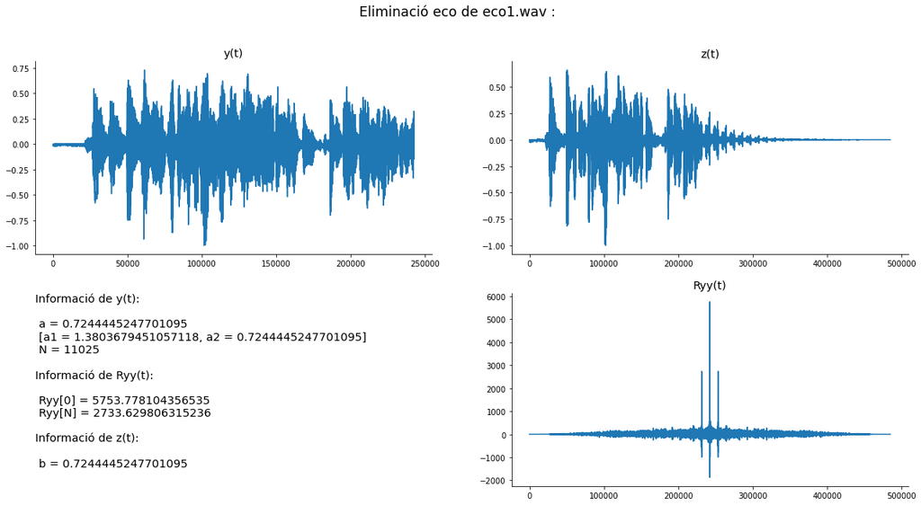

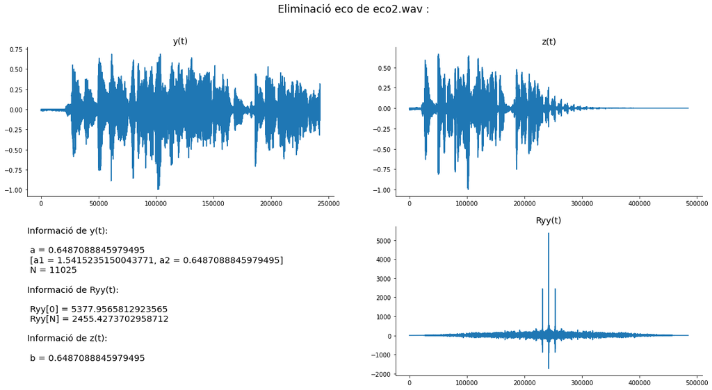

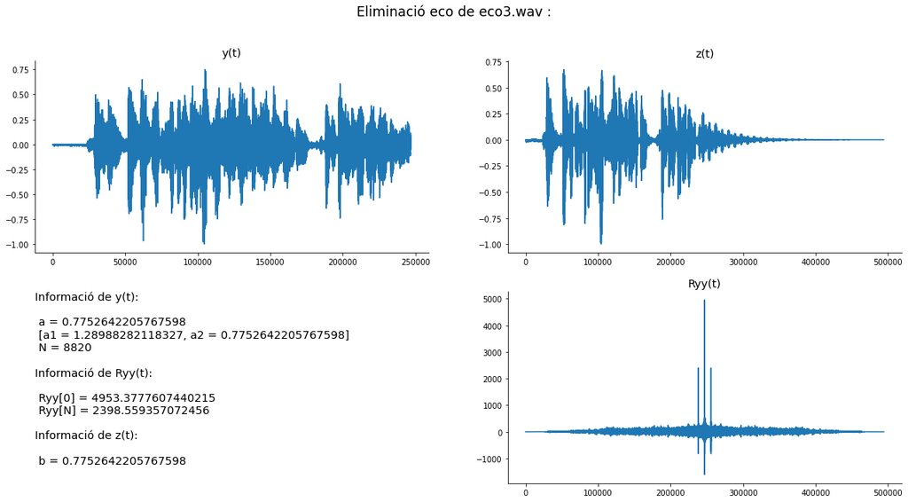

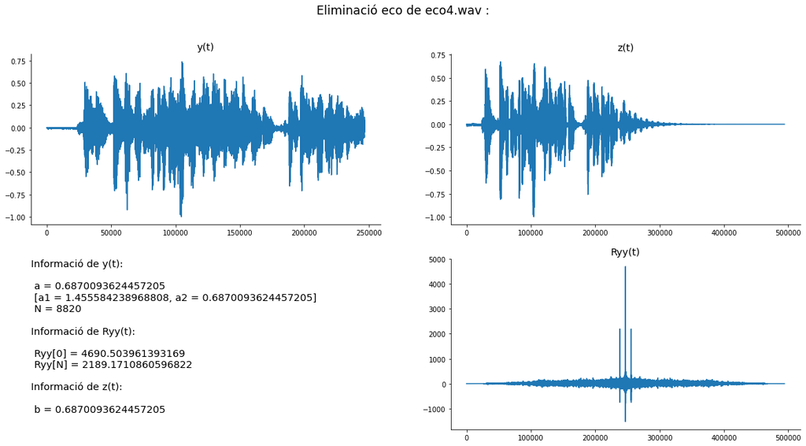

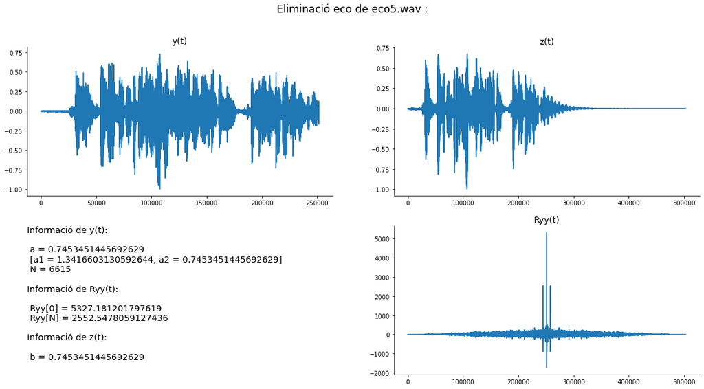

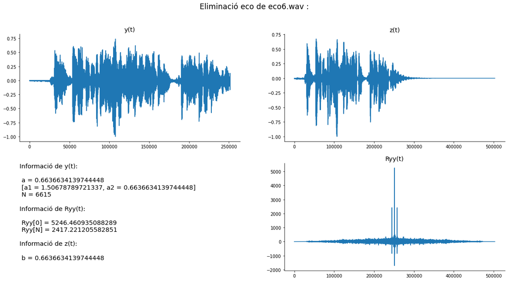

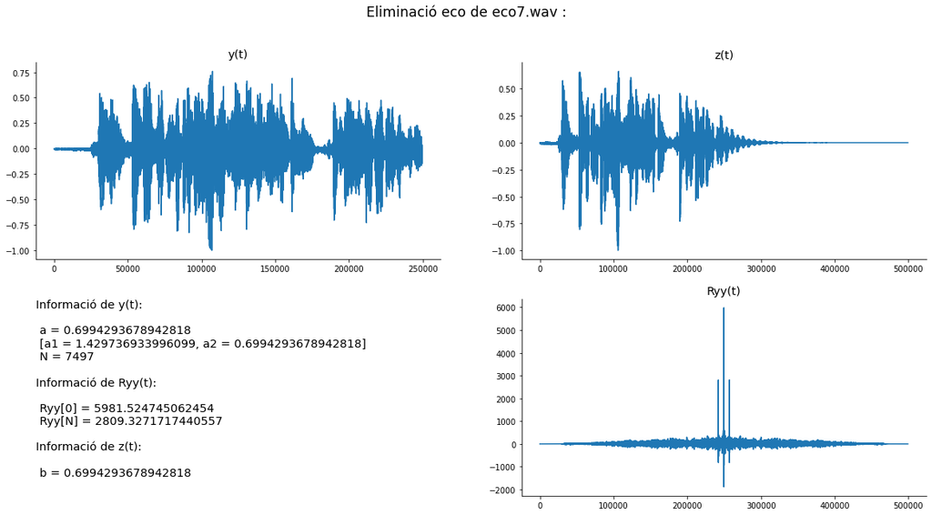

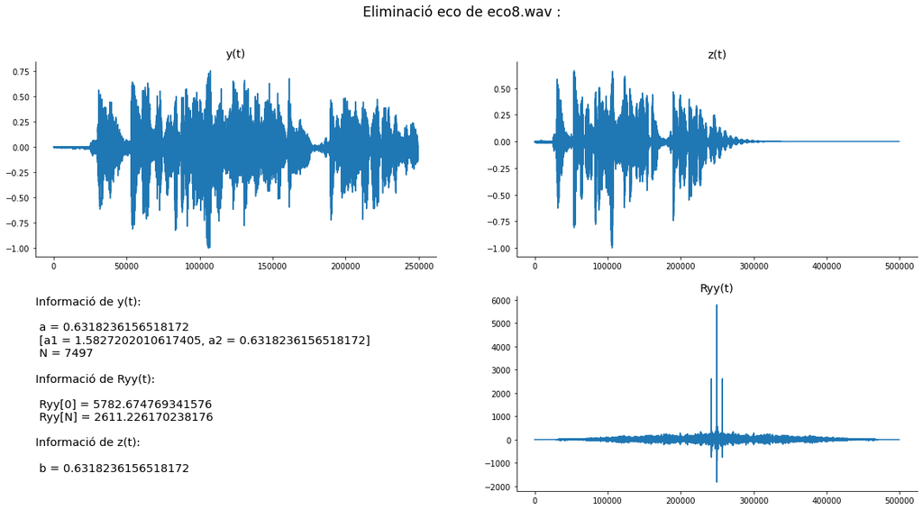

```python
for i in range(1, 9):
    elim_eco('eco' +str(i)+ '.wav')
```